# Search: Solving a Maze Using a Goal-based Agent

## Task 3: Informed search: Implement greedy best-first search and A* search [20 Points]

You can use the map to estimate the distance from your current position to the goal using the Manhattan distance (see https://en.wikipedia.org/wiki/Taxicab_geometry) as a heuristic function. Both algorithms are based on Best-First search which requires only a small change from the BFS algorithm you have already implemented (see textbook/slides).

```python
import numpy as np
def manhattan(pos1, pos2):
    """returns the Manhattan distance between two positions"""
    return(np.sum(np.abs(np.subtract(pos1, pos2))))

#print(manhattan((0,0), (1,1)))
```

```python
# BestFS definition based on BFS
import heapq
import matplotlib.pyplot as plt
def BestFS(maze, f = 1, animation = True):
  order = 0
  max_depth = 0
  max_frontier = 0
  depth = 0
  start = mh.find_pos(maze, what = "S")
  goal = mh.find_pos(maze, what = "G")
  results = {'path': [], 'reached': [], 'actions': [], 'maze_anim': []}
  actions = []
  maze_snap = maze.copy()
  maze_anim = []
  node = Node(start, None, None, 0)
  if (node.pos == goal):
    return node
  frontier = []
  heapq.heappush(frontier, (manhattan(start, goal), order, node))
  reached = {start:node} # total number of nodes
  path = [[start]] # solution and path cost as length of path #########

  while (len(frontier) != 0):
    # print(curr_path)
    if len(frontier) > max_frontier: max_frontier = len(frontier) # max frontier
    node = (heapq.heappop(frontier))[2]
    maze_snap = maze_snap.copy()
    maze_snap[node.pos[0], node.pos[1]] = 'P'
    for child in expand(maze, node):
      child_depth = len(child.get_path_from_root())
      child.cost = child_depth
      #print("child cost: ", child_depth)
      #new_path = curr_path
      #print(depth)
      #depth += 1 # track depth
      s = child.pos
      if (child.pos == goal):
        maze_snap[p.pos[0], p.pos[1]] = 'P'
        maze_snap[start[0], start[1]] = 'S'
        maze_snap[goal[0], goal[1]] = 'G'
      #mh.show_maze(maze_snap)
        maze_anim.append(maze_snap)
        if animation:
          results['reached'] = reached
          results['actions'] = actions
          results['path'] = path[-1]
          results['maze_anim'] = maze_anim
          # for mz in maze_anim:
          #   mh.show_maze(mz)
          #   print(mh.maze_to_matrix(mz))
          return results, max_depth, max_frontier
      if (node.pos == goal):
        curr_path = node.get_path_from_root()
        path.append([n.pos for n in curr_path])
        if animation:
          results['reached'] = reached
          results['actions'] = actions
          results['path'] = path[-1]
          results['maze_anim'] = maze_anim
          return results, max_depth, max_frontier
      if len(maze_anim) > 1: maze_snap = maze_reset
      if (s not in reached) or (child.cost < reached[s].cost):
        reached[s] = child

        #print(child_depth)
        heapq.heappush(frontier, (manhattan(child.pos, goal), order, child)) ########### manhattan
        order += 1
        actions.append(child.action)
        maze_snap[s[0], s[1]] = 'F'
      curr_path = node.get_path_from_root()
      if len(curr_path) > depth: depth = len(curr_path)
      path.append([n.pos for n in curr_path])
      for p in curr_path:
        if maze_snap[p.pos[0], p.pos[1]] != 'F':
          maze_snap[p.pos[0], p.pos[1]] = 'P'
      maze_snap[start[0], start[1]] = 'S'
      maze_snap[goal[0], goal[1]] = 'G'
      #mh.show_maze(maze_snap)
      maze_anim.append(maze_snap)
      maze_reset = maze_snap.copy()
      for p in curr_path:
        maze_reset[p.pos[0], p.pos[1]] = '.'
      maze_snap[start[0], start[1]] = 'S'
      maze_snap[goal[0], goal[1]] = 'G'
      # if (node.pos[0], node.pos[1]) != (start[0], start[1]):
      #   maze_snap[node.pos[0], node.pos[1]] = '.'
      if depth > max_depth: max_depth = depth

  # if animation:
  #   results['reached'] = reached
  #   results['actions'] = actions
  #   results['path'] = path
  #   results['maze_anim'] = maze_anim
  #   return results results, max_depth, total_nodes, max_frontier
  return -1
```

```python
f = open("medium_maze.txt", "r")
#f = open("large_maze.txt", "r")    # this has only one solution!
#f = open("open_maze.txt", "r")
#f = open("empty_maze.txt", "r")
#f = open("empty_2_maze.txt", "r")
#f = open("wall_maze.txt", "r")
#f = open("loops_maze.txt", "r")
#f = open("L_maze.txt", "r")

maze_str = f.read()
maze = mh.parse_maze(maze_str)
maze_result, max_depth, max_frontier = BestFS(maze)
print("Path Cost: ", len(maze_result['path']) - 1, "\nTotal Number of Nodes: ", len(maze_result['reached']),
      "\nMax Frontier: ", max_frontier, "\nMax Depth: ", max_depth - 1)
mh.animate_maze(maze_result)
```

```
Path Cost:  72
Total Number of Nodes:  81
Max Frontier:  4
Max Depth:  72
Path length: 72
Reached squares: 81
Action sequence: ['S', 'W', 'S', 'W', 'W', 'W', 'W', 'S', 'S', 'E', 'E', 'E', 'E', 'S', 'S', 'W', 'W', 'W', 'W', 'S', 'W', 'S', 'E', 'E', 'E', 'E', 'S', 'S', 'W', 'W', 'W', 'W', 'S', 'W', 'S', 'E', 'S', 'E', 'E', 'E', 'E', 'S', 'S', 'S', 'W', 'W', 'W', 'W', 'W', 'W', 'W', 'N', 'N', 'W', 'W', 'W', 'W…
```

[video not shown]

```python
# A* search based on BestFS
import heapq
import matplotlib.pyplot as plt
def A(maze, f = 1, animation = True):
  order = 0
  max_depth = 0
  max_frontier = 0
  depth = 0
  start = mh.find_pos(maze, what = "S")
  goal = mh.find_pos(maze, what = "G")
  results = {'path': [], 'reached': [], 'actions': [], 'maze_anim': []}
  actions = []
  maze_snap = maze.copy()
  maze_anim = []
  node = Node(start, None, None, 0)
  if (node.pos == goal):
    return node
  frontier = []
  heapq.heappush(frontier, (manhattan(start, goal), order, node))
  reached = {start:node} # total number of nodes
  path = [[start]] # solution and path cost as length of path #########

  while (len(frontier) != 0):
    # print(curr_path)
    if len(frontier) > max_frontier: max_frontier = len(frontier) # max frontier
    node = (heapq.heappop(frontier))[2]
    maze_snap = maze_snap.copy()
    maze_snap[node.pos[0], node.pos[1]] = 'P'
    for child in expand(maze, node):
      child_depth = len(child.get_path_from_root())
      child.cost = child_depth
      s = child.pos
      if (child.pos == goal):
        maze_snap[p.pos[0], p.pos[1]] = 'P'
        maze_snap[start[0], start[1]] = 'S'
        maze_snap[goal[0], goal[1]] = 'G'
        maze_anim.append(maze_snap)
        if animation:
          results['reached'] = reached
          results['actions'] = actions
          results['path'] = path[-1]
          results['maze_anim'] = maze_anim
          return results, max_depth, max_frontier
      if (node.pos == goal):
        curr_path = node.get_path_from_root()
        path.append([n.pos for n in curr_path])
        if animation:
          results['reached'] = reached
          results['actions'] = actions
          results['path'] = path[-1]
          results['maze_anim'] = maze_anim
          return results, max_depth, max_frontier
      if len(maze_anim) > 1: maze_snap = maze_reset
      if (s not in reached) or (child.cost < reached[s].cost):
        reached[s] = child
        heapq.heappush(frontier, (manhattan(child.pos, goal) + child_depth, order, child)) ########### manhattan
        order += 1
        actions.append(child.action)
        maze_snap[s[0], s[1]] = 'F'
      curr_path = node.get_path_from_root()
      if len(curr_path) > depth: depth = len(curr_path)
      path.append([n.pos for n in curr_path])
      for p in curr_path:
        if maze_snap[p.pos[0], p.pos[1]] != 'F':
          maze_snap[p.pos[0], p.pos[1]] = 'P'
      maze_snap[start[0], start[1]] = 'S'
      maze_snap[goal[0], goal[1]] = 'G'
      maze_anim.append(maze_snap)
      maze_reset = maze_snap.copy()
      for p in curr_path:
        maze_reset[p.pos[0], p.pos[1]] = '.'
      maze_snap[start[0], start[1]] = 'S'
      maze_snap[goal[0], goal[1]] = 'G'
      if depth > max_depth: max_depth = depth
  return -1
```

```python
#f = open("medium_maze.txt", "r")
f = open("medium_maze.txt", "r")
#f = open("large_maze.txt", "r")    # this has only one solution!
#f = open("open_maze.txt", "r")
#f = open("empty_maze.txt", "r")
#f = open("empty_2_maze.txt", "r")
#f = open("wall_maze.txt", "r")
#f = open("loops_maze.txt", "r")
#f = open("L_maze.txt", "r")

maze_str = f.read()
maze = mh.parse_maze(maze_str)
maze_result, max_depth, max_frontier = A(maze)
print("Path Cost: ", len(maze_result['path']) - 1, "\nTotal Number of Nodes: ", len(maze_result['reached']),
      "\nMax Frontier: ", max_frontier, "\nMax Depth: ", max_depth - 1)
mh.animate_maze(maze_result)
```

```
Path Cost:  66
Total Number of Nodes:  227
Max Frontier:  8
Max Depth:  66
Path length: 66
Reached squares: 227
Action sequence: ['S', 'W', 'S', 'W', 'W', 'W', 'W', 'W', 'W', 'W', 'W', 'W', 'S', 'W', 'S', 'W', 'E', 'W', 'S', 'W', 'S', 'W', 'E', 'W', 'W', 'W', 'W', 'W', 'W', 'W', 'W', 'W', 'W', 'W', 'W', 'W', 'W', 'W', 'W', 'W', 'W', 'W', 'W', 'W', 'W', 'S', 'S', 'S', 'S', 'S', 'S', 'S', 'S', 'S', 'E', 'E', 'E…
```

[video not shown]

Are your implementations complete and optimal? What is the time and space complexity?

```python
# BestFS:
  # complete: Yes, Best-first search is complete in finite spaces liek the mazes provided.
  # optimal:
  # time: Worst case: O(bm) (like DFS) and Best case: O(bm) – If ℎ(n) is 100% accurate we only expand a single path,
        # where b is max branching factor and m is max depth.
  # space: same as time complexity ^

# A*:
  # complete: Yes
  # optimal: Yes, No other tree-based search algorithm that uses the same heuristic can expand fewer nodes and still be
            # guaranteed to find the optimal solution.
  # time: Number of nodes for which 𝑓(n) ≤ 𝐶* in the worst case 𝑂(𝑏^𝑑) like BFS.
  # space: Same as time complexity ^
```

## Task 4: Comparison and discussion [20 Points]

Run experiments to compare the implemented algorithms.

How to deal with issues:

- Your implementation returns unexpected results: Try to debug and fix the code. Visualizing the maze, the current path and the frontier after every step is very helpful. If the code still does not work, then mark the result with an asterisk (*) and describe the issue below the table.
- Your implementation cannot consistently solve a specific maze and ends up in an infinite loop: Debug (likely your frontier and cycle checking for DFS are the issue). If it is a shortcoming of the algorithm/implementation, then put "N/A*" in the results table and describe why this is happening.

```python
# Define all mazes
small = open("small_maze.txt", "r")
medium = open("medium_maze.txt", "r")
large = open("large_maze.txt", "r")    # this has only one solution!
op = open("open_maze.txt", "r")
em = open("empty_maze.txt", "r")
em2 = open("empty_2_maze.txt", "r")
wall = open("wall_maze.txt", "r")
loop = open("loops_maze.txt", "r")
L = open("L_maze.txt", "r")

mazes = {"SMALL":small, "MEDIUM":medium, "LARGE":large, "OPEN":op, "EMPTY":em, "EMPTY2":em2, "WALL":wall, "LOOP":loop, "L":L}
```

```python
# BFS data

BFS_data = {}
for key, value in mazes.items():
  maze_str = value.read()
  maze = mh.parse_maze(maze_str)
    #print("-------------------", key, "--------------------")
  maze_result, max_dep, max_front = BFS(maze)
  path_cost = len(maze_result['path'])
  reached = len(maze_result['reached'])
  max_frontier = max_front
  max_depth = max_dep
  BFS_data[key] = [np.mean(path_cost), np.mean(reached), np.mean(max_frontier), np.mean(max_depth)]
```

```python
print(BFS_data)
```

```
{'SMALL': [19.0, 92.0, 9.0, 19.0], 'MEDIUM': [68.0, 269.0, 9.0, 68.0], 'LARGE': [210.0, 621.0, 8.0, 210.0], 'OPEN': [54.0, 682.0, 25.0, 54.0], 'EMPTY': [14.0, 95.0, 12.0, 14.0], 'EMPTY2': [14.0, 95.0, 11.0, 14.0], 'WALL': [14.0, 88.0, 11.0, 14.0], 'LOOP': [23.0, 71.0, 8.0, 23.0], 'L': [16.0, 151.0, …
```

```python
# DFS data

DFS_data = {}
for key, value in mazes.items():
  maze_str = value.read()
  maze = mh.parse_maze(maze_str)
    #print("-------------------", key, "--------------------")
  maze_result, max_dep, max_front = DFS(maze)
  path_cost = len(maze_result['path'])
  reached = len(maze_result['reached'])
  max_frontier = max_front
  max_depth = max_dep
  DFS_data[key] = [np.mean(path_cost), np.mean(reached), np.mean(max_frontier), np.mean(max_depth)]
```

```python
print(DFS_data)
```

```
{'SMALL': [29.0, 40.0, 5.0, 29.0], 'MEDIUM': [152.0, 154.0, 8.0, 152.0], 'LARGE': [210.0, 338.0, 38.0, 215.0], 'OPEN': [54.0, 212.0, 63.0, 179.0], 'EMPTY': [80.0, 81.0, 12.0, 80.0], 'EMPTY2': [34.0, 35.0, 32.0, 34.0], 'WALL': [64.0, 82.0, 19.0, 73.0], 'LOOP': [27.0, 31.0, 11.0, 27.0], 'L': [122.0, 1…
```

```python
# BestFS data
BestFS_data = {}
for key, value in mazes.items():
  maze_str = value.read()
  maze = mh.parse_maze(maze_str)
    #print("-------------------", key, "--------------------")
  maze_result, max_dep, max_front = BestFS(maze)
  path_cost = len(maze_result['path'])
  reached = len(maze_result['reached'])
  max_frontier = max_front
  max_depth = max_dep
  #print("Path Cost: ", len(maze_result['path']) - 1, "\nTotal Number of Nodes: ", len(maze_result['reached']), "\nMax Frontier: ", max_frontier, "\nMax Depth: ", max_depth - 1)
  BestFS_data[key] = [path_cost, reached, max_frontier, max_depth]
```

```python
print(BestFS_data)
```

```
{'SMALL': [28.0, 43.0, 5.0, 28.0], 'MEDIUM': [73.0, 81.0, 4.0, 73.0], 'LARGE': [209.0, 486.0, 21.0, 209.0], 'OPEN': [68.0, 154.0, 65.0, 68.0], 'EMPTY': [14.0, 41.0, 27.0, 14.0], 'EMPTY2': [14.0, 42.0, 27.0, 14.0], 'WALL': [14.0, 41.0, 27.0, 14.0], 'LOOP': [23.0, 60.0, 10.0, 23.0], 'L': [24.0, 57.0, …
```

```python
# A data
A_data = {}
for key, value in mazes.items():
  maze_str = value.read()
  maze = mh.parse_maze(maze_str)
    #print("-------------------", key, "--------------------")
  maze_result, max_dep, max_front = A(maze)
  path_cost = len(maze_result['path'])
  reached = len(maze_result['reached'])
  max_frontier = max_front
  max_depth = max_dep
  A_data[key] = [np.mean(path_cost), np.mean(reached), np.mean(max_frontier), np.mean(max_depth)]
```

```python
print(A_data)
```

```
{'SMALL': [18.0, 58.0, 8.0, 18.0], 'MEDIUM': [67.0, 227.0, 8.0, 67.0], 'LARGE': [209.0, 556.0, 12.0, 209.0], 'OPEN': [54.0, 554.0, 25.0, 54.0], 'EMPTY': [14.0, 92.0, 30.0, 14.0], 'EMPTY2': [14.0, 92.0, 30.0, 14.0], 'WALL': [14.0, 85.0, 30.0, 14.0], 'LOOP': [23.0, 61.0, 6.0, 23.0], 'L': [16.0, 76.0, …
```

```python
# Combine data into df
# path cost, reached, max frontier, max depth
import pandas as pd
Adf = pd.DataFrame(A_data).T
Adf = Adf.rename(columns={Adf.columns[0]: "Path Cost", Adf.columns[1]: "Reached", Adf.columns[2]: "Max Frontier", Adf.columns[3]: "Max Depth"})
Adf['Nodes in Memory'] = Adf['Reached']
# print("A* SEARCH")

BestFSdf = pd.DataFrame(BestFS_data).T
BestFSdf = BestFSdf.rename(columns={BestFSdf.columns[0]: "Path Cost", BestFSdf.columns[1]: "Reached", BestFSdf.columns[2]: "Max Frontier", BestFSdf.columns[3]: "Max Depth"})
BestFSdf['Nodes in Memory'] = BestFSdf['Path Cost']
# print("BEST FS SEARCH")

DFSdf = pd.DataFrame(DFS_data).T
DFSdf = DFSdf.rename(columns={DFSdf.columns[0]: "Path Cost", DFSdf.columns[1]: "Reached", DFSdf.columns[2]: "Max Frontier", DFSdf.columns[3]: "Max Depth"})
DFSdf['Nodes in Memory'] = DFSdf['Path Cost']
# print("DFS SEARCH")

BFSdf = pd.DataFrame(BFS_data).T
BFSdf = BFSdf.rename(columns={BFSdf.columns[0]: "Path Cost", BFSdf.columns[1]: "Reached", BFSdf.columns[2]: "Max Frontier", BFSdf.columns[3]: "Max Depth"})
BFSdf['Nodes in Memory'] = BFSdf['Reached']
# print("BFS SEARCH")

def restructure_df(df, algorithm_name):
    # Add an 'Algorithm' column for identification
    df['Algorithm'] = algorithm_name
    return df

# Apply this function to each of the algorithm DataFrames
Adf = restructure_df(Adf, "A*")
BestFSdf = restructure_df(BestFSdf, "Best FS")
DFS = restructure_df(DFSdf, "DFS")
BFSdf = restructure_df(BFSdf, "BFS")

# Combine the DataFrames into one large DataFrame for easier manipulation
combined_df = pd.concat([Adf, BestFSdf, DFS, BFSdf])

# Display the data grouped by maze type and algorithm
maze_types = combined_df.index.unique()  # Get unique maze types (index values)
results = []
# Loop through each maze type and print the table for each algorithm
for maze in maze_types:
    print(f"__{maze} Maze__\n")

    # Filter the combined DataFrame by the current maze type
    maze_data = combined_df.loc[maze]

    # Print the table header
    print("| algorithm | path cost | # of nodes expanded | max tree depth | max # of nodes in memory | max frontier size |")
    print("|-----------|-----------|--------------------|----------------|--------------------------|-------------------|")

    # Iterate through each algorithm in the maze data
    for algorithm in maze_data['Algorithm'].unique():
        # Get the data for the current algorithm
        algorithm_data = maze_data[maze_data['Algorithm'] == algorithm].iloc[0]

        # Print the row for this algorithm
        print(f"| {algorithm:<9} | {algorithm_data['Path Cost']:<9} | {algorithm_data['Reached']:<18} | "
              f"{algorithm_data['Max Depth']:<14} | {algorithm_data['Nodes in Memory']:<24} | "
              f"{algorithm_data['Max Frontier']:<17} |")
    print("\n")

    # Iterate through each algorithm in the maze data
    for algorithm in maze_data['Algorithm'].unique():
        algorithm_data = maze_data[maze_data['Algorithm'] == algorithm].iloc[0]

        # Append the result as a dictionary to the results list
        results.append({
            'Maze': maze,
            'Algorithm': algorithm,
            'Path Cost': algorithm_data['Path Cost'],
            'Reached': algorithm_data['Reached'],
            'Max Depth': algorithm_data['Max Depth'],
            'Max Frontier': algorithm_data['Max Frontier'],
            'Nodes in Memory': algorithm_data['Nodes in Memory']
        })

# Convert the results list into a DataFrame
final_df = pd.DataFrame(results)

# Now `final_df` contains all the results
#print(final_df)
```

```
__SMALL Maze__

| algorithm | path cost | # of nodes expanded | max tree depth | max # of nodes in memory | max frontier size |
|-----------|-----------|--------------------|----------------|--------------------------|-------------------|
| A*        | 18.0      | 58.0               | 18.0           | 58.0                     | 8.0               |
| Best FS   | 28.0      | 43.0               | 28.0           | 28.0                     | 5.0               |
| DFS       | 29.0      | 40.0               | 29.0           | 29.0                     | 5.0               |
| BFS       | 19.0      | 92.0               | 19.0           | 92.0                     | 9.0               |


__MEDIUM Maze__

| algorithm | path cost | # of nodes expanded | max tree depth | max # of nodes in memory | max frontier size |
|-----------|-----------|--------------------|----------------|--------------------------|-------------------|
| A*        | 67.0      | 227.0              | 67.0           | 227.0                    | 8.0               |
| Best FS   | 73.0      | 81.0               | 73.0           | 73.0                     | 4.0               |
| DFS       | 152.0     | 154.0              | 152.0          | 152.0                    | 8.0               |
| BFS       | 68.0      | 269.0              | 68.0           | 269.0                    | 9.0               |


__LARGE Maze__

| algorithm | path cost | # of nodes expanded | max tree depth | max # of nodes in memory | max frontier size |
|-----------|-----------|--------------------|----------------|--------------------------|-------------------|
| A*        | 209.0     | 556.0              | 209.0          | 556.0                    | 12.0              |
| Best FS   | 209.0     | 486.0              | 209.0          | 209.0                    | 21.0              |
| DFS       | 210.0     | 338.0              | 215.0          | 210.0                    | 38.0              |
| BFS       | 210.0     | 621.0              | 210.0          | 621.0                    | 8.0               |


__OPEN Maze__

| algorithm | path cost | # of nodes expanded | max tree depth | max # of nodes in memory | max frontier size |
|-----------|-----------|--------------------|----------------|--------------------------|-------------------|
| A*        | 54.0      | 554.0              | 54.0           | 554.0                    | 25.0              |
| Best FS   | 68.0      | 154.0              | 68.0           | 68.0                     | 65.0              |
| DFS       | 54.0      | 212.0              | 179.0          | 54.0                     | 63.0              |
| BFS       | 54.0      | 682.0              | 54.0           | 682.0                    | 25.0              |


```

[output cut: 33 more lines]

```
|-----------|-----------|--------------------|----------------|--------------------------|-------------------|
| A*        | 23.0      | 61.0               | 23.0           | 61.0                     | 6.0               |
| Best FS   | 23.0      | 60.0               | 23.0           | 23.0                     | 10.0              |
| DFS       | 27.0      | 31.0               | 27.0           | 27.0                     | 11.0              |
| BFS       | 23.0      | 71.0               | 23.0           | 71.0                     | 8.0               |


__L Maze__

| algorithm | path cost | # of nodes expanded | max tree depth | max # of nodes in memory | max frontier size |
|-----------|-----------|--------------------|----------------|--------------------------|-------------------|
| A*        | 16.0      | 76.0               | 16.0           | 76.0                     | 24.0              |
| Best FS   | 24.0      | 57.0               | 24.0           | 24.0                     | 29.0              |
| DFS       | 122.0     | 133.0              | 122.0          | 122.0                    | 23.0              |
| BFS       | 16.0      | 151.0              | 16.0           | 151.0                    | 17.0              |
```

Complete the following table for each maze. COMPLETED ABOVE

**Small maze**

[output not shown]

**Medium Maze**

Present the results as using charts (see Python Code Examples/charts and tables).

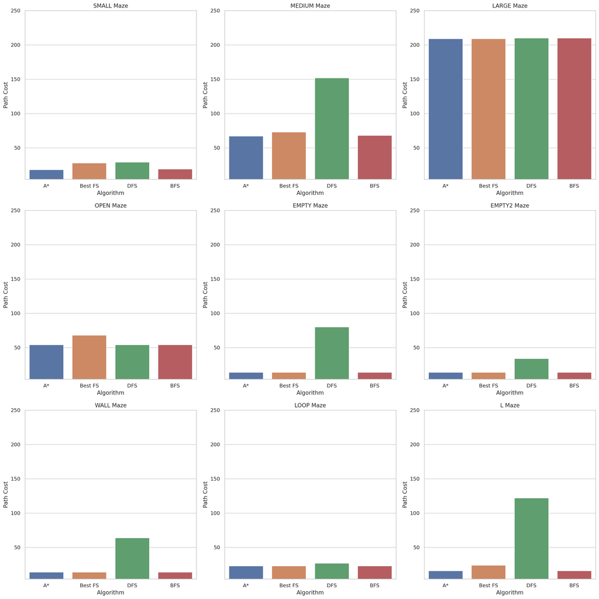

```python
import matplotlib.pyplot as plt
import seaborn as sns

# Set the style for seaborn (optional)
sns.set(style="whitegrid")

# Get the unique maze types
maze_types = final_df['Maze'].unique()

# Define the features to be plotted
features = ['Path Cost', 'Reached', 'Max Depth', 'Max Frontier', 'Nodes in Memory']

# Create a figure with 3x3 subplots
fig, axes = plt.subplots(3, 3, figsize=(18, 18))

# Flatten the axes array for easier iteration
axes = axes.flatten()

# Set the y-axis limits (same for all plots)
y_limit_min = final_df[features].min().min()
y_limit_max = 250#final_df[features].max().max()

# Iterate through each maze type and plot on the corresponding subplot
for i, maze in enumerate(maze_types):
    ax = axes[i]

    # Filter the data for the current maze type
    maze_data = final_df[final_df['Maze'] == maze]

    # Create a bar plot for each feature, grouped by Algorithm
    sns.barplot(x="Algorithm", y="Path Cost", hue="Algorithm", data=maze_data, ax=ax)

    # Set the title of the plot for the current maze
    ax.set_title(f'{maze} Maze')

    # Set the y-axis limit (same for all plots)
    ax.set_ylim(y_limit_min, y_limit_max)

    # Rotate x-axis labels for better readability
    # ax.set_xticklabels(ax.get_xticklabels(), rotation=45, ha="right")
# Adjust the layout so the plots don't overlap
plt.tight_layout()

# Show the plot
plt.show()
```

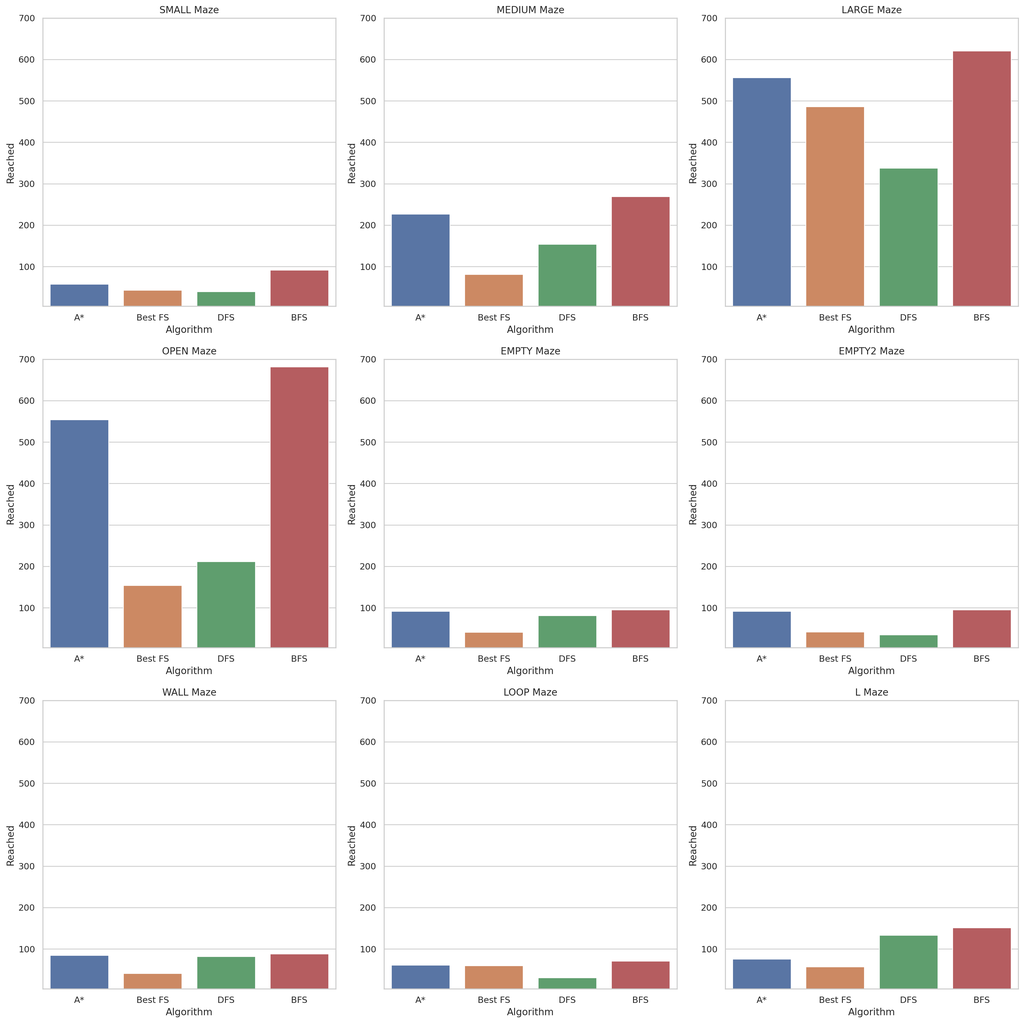

```python
# Reached Comparison

fig, axes = plt.subplots(3, 3, figsize=(18, 18))

axes = axes.flatten()

y_limit_min = final_df[features].min().min()
y_limit_max = 700

for i, maze in enumerate(maze_types):
    ax = axes[i]

    maze_data = final_df[final_df['Maze'] == maze]

    sns.barplot(x="Algorithm", y="Reached", hue="Algorithm", data=maze_data, ax=ax)
    ax.set_title(f'{maze} Maze')

    ax.set_ylim(y_limit_min, y_limit_max)

plt.tight_layout()
plt.show()
```

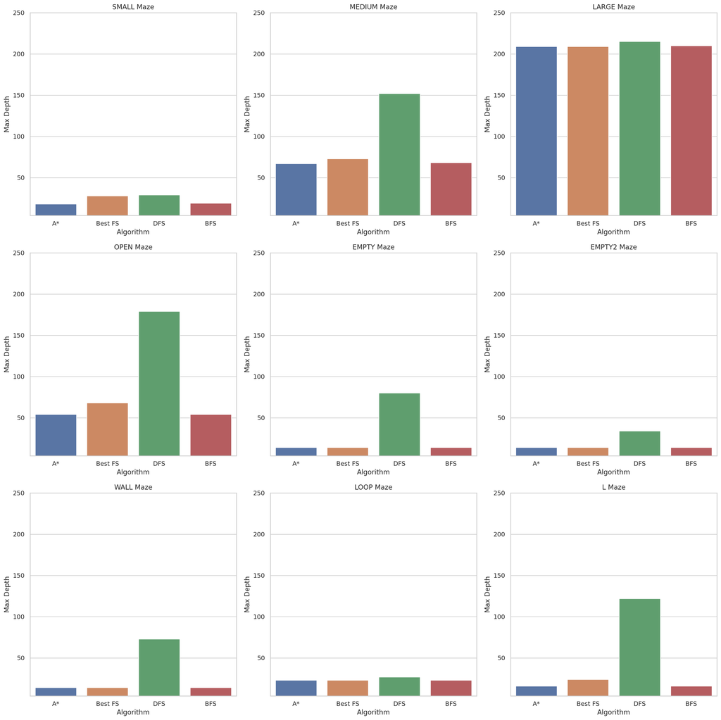

```python
fig, axes = plt.subplots(3, 3, figsize=(18, 18))

axes = axes.flatten()

y_limit_min = final_df[features].min().min()
y_limit_max = 250

for i, maze in enumerate(maze_types):
    ax = axes[i]

    maze_data = final_df[final_df['Maze'] == maze]

    sns.barplot(x="Algorithm", y="Max Depth", hue="Algorithm", data=maze_data, ax=ax)
    ax.set_title(f'{maze} Maze')

    ax.set_ylim(y_limit_min, y_limit_max)

plt.tight_layout()
plt.show()
```

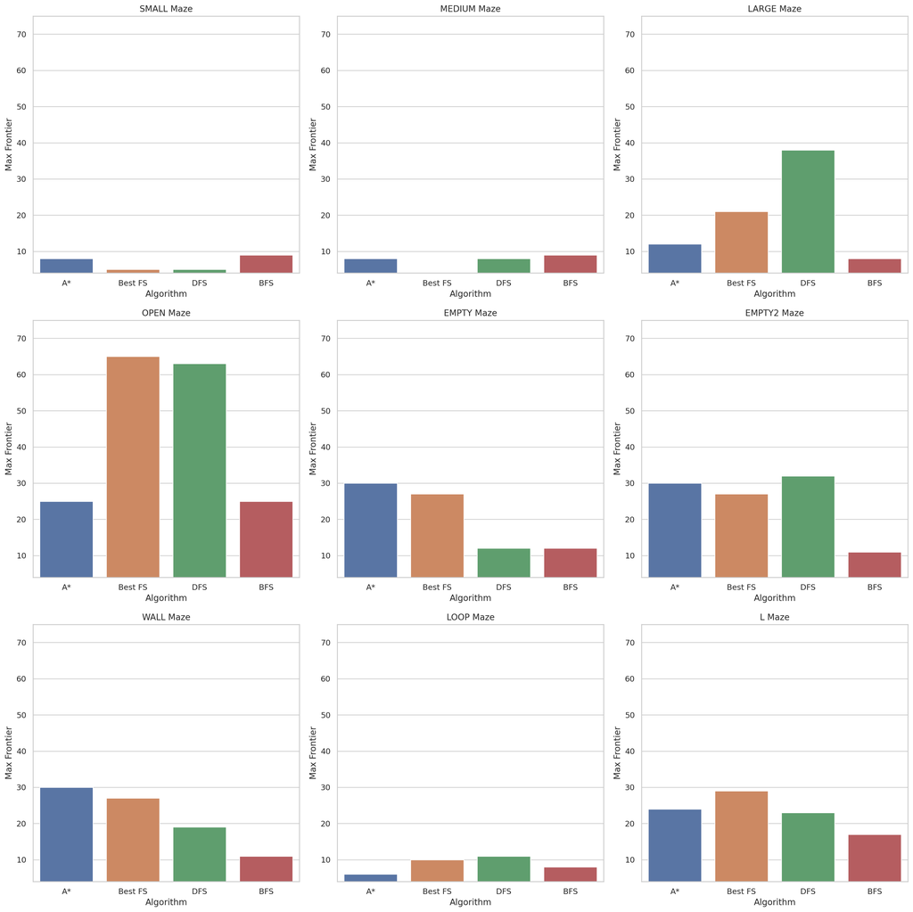

```python
fig, axes = plt.subplots(3, 3, figsize=(18, 18))

axes = axes.flatten()

y_limit_min = final_df[features].min().min()
y_limit_max = 75

for i, maze in enumerate(maze_types):
    ax = axes[i]

    maze_data = final_df[final_df['Maze'] == maze]

    sns.barplot(x="Algorithm", y="Max Frontier", hue="Algorithm", data=maze_data, ax=ax)
    ax.set_title(f'{maze} Maze')

    ax.set_ylim(y_limit_min, y_limit_max)

plt.tight_layout()
plt.show()
```

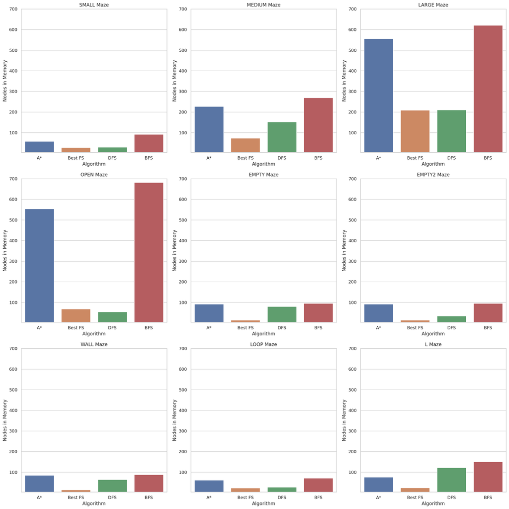

```python
fig, axes = plt.subplots(3, 3, figsize=(18, 18))

axes = axes.flatten()

y_limit_min = final_df[features].min().min()
y_limit_max = 700

for i, maze in enumerate(maze_types):
    ax = axes[i]

    maze_data = final_df[final_df['Maze'] == maze]

    sns.barplot(x="Algorithm", y="Nodes in Memory", hue="Algorithm", data=maze_data, ax=ax)
    ax.set_title(f'{maze} Maze')

    ax.set_ylim(y_limit_min, y_limit_max)

plt.tight_layout()
plt.show()
```

Discuss the most important lessons you have learned from implementing the different search strategies.

```python
# I was aware of different algorithms that find the same solution in different ways but seeing it through the animations and how adjustments I made affected that was interesting.
# Working around memory by removing the visited/reached data sctructure was a different kind of challenge to work with and seeing how that affects the algorithm through the animation was helpful.
# A very simple and easy introduction to using heuristics and improving them based on the environment (BestFS -> A*).
# There is no single optimal algo, just one that is better for a certain use ase than others.
```

## Advanced task: IDS and Multiple goals

- **Graduate students** need to complete this task [10 points]
- **Undergraduate students** can attempt this as a bonus task [max +5 bonus points].

### IDS

Implement IDS (iterative deepening search) using your DFS implementation. Test IDS on the mazes above. You may run into some issues with mazes with open spaces. If you cannot resolve the issus, then report and discuss what causes the problems.

```python
def IDS(problem):
  for depth in range(1, 1000):
    result = DFS(problem, depth)
    if result != "cutoff":
      return result
```

```python
import matplotlib.pyplot as plt
def DFS(maze, max_tries = 1000, animation = True):
  max_depth = 0
  max_frontier = 0
  start = mh.find_pos(maze, what = "S")
  goal = mh.find_pos(maze, what = "G")
  results = {'path': [], 'reached': [], 'actions': [], 'maze_anim': []}
  path = [] # solution and path cost as length of path
  actions = []
  maze_snap = maze.copy()
  maze_anim = []
  node = Node(start, None, None, 0)
  if (node.pos == goal):
    return node
  frontier = [node]
  reached = [start] # total number of nodes

  while (len(frontier) != 0):# and (len(frontier[-1].get_path_from_root()) < max_tries):
    # # # print("again")
    if len(frontier) > max_frontier: max_frontier = len(frontier) # max frontier
    node = frontier.pop()
    # print("popped: ", node.pos)
    reached.append(node.pos)

    depth = 0

    d = len(node.get_path_from_root())
    if d > max_tries:
      # if len(frontier) > 1:
      #   depth_list = [len(f.get_path_from_root()) for f in frontier]
      #   #print(depth_list)
      #   lowest_depth = min(depth_list)
      #   while len(frontier[-1].get_path_from_root())>lowest_depth:
      #     frontier.pop()
      #frontier.pop()
      continue
    if (node.pos == goal):
        if animation:
          maze_anim[0][start[0], start[1]] = 'S'
          maze_anim[0][goal[0], goal[1]] = 'G'
          results['reached'] = reached
          results['actions'] = actions
          results['path'] = node.get_path_from_root()#path
          results['maze_anim'] = maze_anim
          return results, max_depth, max_frontier

    if (cycle(node, frontier)) == False:
        for child in expand(maze, node):#, frontier):
          if len(maze_anim) > 1: maze_snap = maze_reset

          s = child.pos
          for c in frontier:
              if c.pos == child.pos:
                  frontier.remove(c)
              # if c in frontier:
              #  frontier.remove(c)
          if (child not in frontier) and (s not in child.get_path_from_root()):
            frontier.append(child)
            # print("appended: ", child.pos)
            actions.append(child.action)
            maze_snap[s[0], s[1]] = 'F'

        curr_path = node.get_path_from_root()
        if len(curr_path) > depth: depth = len(curr_path)
        path.append([n.pos for n in curr_path])
        for p in curr_path:
          #if maze_snap[p.pos[0], p.pos[1]] != 'F':
            maze_snap[p.pos[0], p.pos[1]] = 'P'
        maze_snap[start[0], start[1]] = 'S'
        maze_snap[goal[0], goal[1]] = 'G'
        # mh.show_maze(maze_snap) #######################
        maze_anim.append(maze_snap)
        maze_reset = maze_snap.copy()
        for p in curr_path:
          maze_reset[p.pos[0], p.pos[1]] = ' '
          maze_reset[start[0], start[1]] = 'S'
          maze_reset[goal[0], goal[1]] = 'G'
        if depth > max_depth: max_depth = depth

        if (child.pos == goal):
            ## mh.show_maze(maze_snap)
            maze_snap[child.pos[0], child.pos[1]] = 'P'
            maze_snap[start[0], start[1]] = 'S'
            maze_snap[goal[0], goal[1]] = 'G'
            # mh.show_maze(maze_snap) #########################
            maze_anim.append(maze_snap)
            if animation:
              results['reached'] = reached
              results['actions'] = actions
              results['path'] = path[-1]
              results['maze_anim'] = maze_anim

              return results, max_depth, max_frontier

  return "cutoff"
```

```python
f = open("loops_maze.txt", "r")
f = open("L_maze.txt", "r")
f = open("small_maze.txt", "r")
f = open("empty_2_maze.txt", "r")
f = open("open_maze.txt", "r")
f = open("large_maze.txt", "r")
f = open("wall_maze.txt", "r")
f = open("medium_maze.txt", "r")

maze_str = f.read()
maze = mh.parse_maze(maze_str)
maze_result, max_depth, max_frontier = IDS(maze)
print("Path Cost: ", len(maze_result['path']) - 1, "\nTotal Number of Nodes: ", len(maze_result['reached']),
      "\nMax Frontier: ", max_frontier, "\nMax Depth: ", max_depth - 1)
mh.animate_maze(maze_result)
```

```
Path Cost:  69
Total Number of Nodes:  227
Max Frontier:  8
Max Depth:  69
Path length: 69
Reached squares: 227
Action sequence: ['S', 'W', 'W', 'W', 'W', 'W', 'W', 'W', 'W', 'W', 'S', 'W', 'W', 'W', 'W', 'W', 'W', 'W', 'W', 'W', 'W', 'W', 'W', 'W', 'W', 'W', 'W', 'W', 'W', 'W', 'W', 'W', 'W', 'W', 'W', 'S', 'S', 'S', 'S', 'S', 'S', 'S', 'S', 'S', 'E', 'E', 'E', 'N', 'N', 'N', 'N', 'W', 'N', 'N', 'N', 'E', 'E…
```

[video not shown]

```python
f = open("empty_maze.txt", "r")

maze_str = f.read()
maze = mh.parse_maze(maze_str)
maze_result, max_depth, max_frontier = IDS(maze)
print("Path Cost: ", len(maze_result['path']) - 1, "\nTotal Number of Nodes: ", len(maze_result['reached']),
      "\nMax Frontier: ", max_frontier, "\nMax Depth: ", max_depth - 1)
mh.animate_maze(maze_result)
```

```
Path Cost:  20
Total Number of Nodes:  503
Max Frontier:  16
Max Depth:  20
Path length: 20
Reached squares: 503
Action sequence: ['N', 'E', 'S', 'W', 'N', 'S', 'E', 'E', 'N', 'E', 'N', 'E', 'N', 'E', 'N', 'E', 'N', 'E', 'N', 'E', 'N', 'E', 'N', 'N', 'W', 'N', 'W', 'N', 'W', 'N', 'W', 'N', 'W', 'N', 'W', 'N', 'W', 'N', 'N', 'E', 'W', 'N', 'E', 'W', 'N', 'S', 'W', 'N', 'S', 'W', 'W', 'N', 'E', 'W', 'N', 'E', 'N…
```

[video not shown]

#### Discussion

IDS seems to work better for some of the mazes where the goal is clsoer to the start. However, my implementation seems to be flawed as the frontier does not get properly handled and many froniter nodes remain even after that depth shoudl have been removed and replaced with a new path to be explored. With more time I would find the error (likely something small but well hidden in my very messy ugly code) and there would be an imrpovement in the open space when using IDS as it would not continue exploring in seemingly random areas outside of the defined algorithm.

### Multiple Goals

Create a few mazes with multiple goals by adding one or two more goals to the medium size maze. The agent is done when it finds one of the goals. Solve the maze with your implementations for DFS, BFS, and IDS. Run experiments to show which implementations find the optimal solution and which do not. Discuss why that is the case.

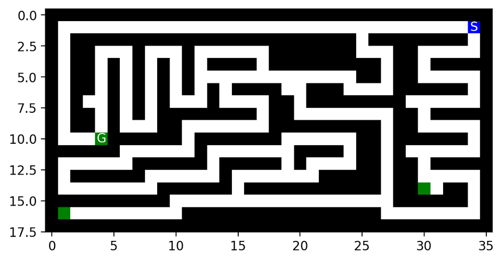

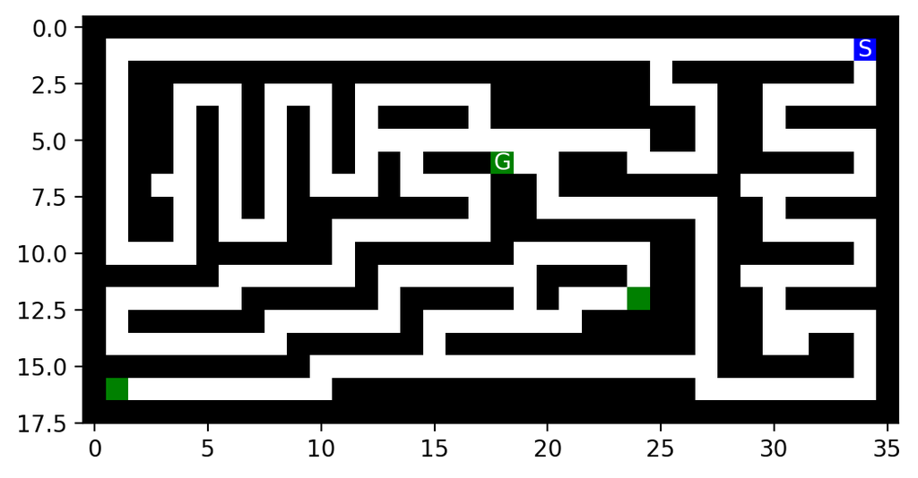

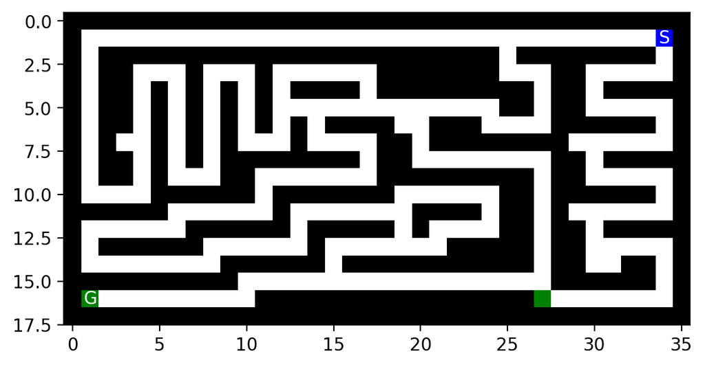

```python
f = open("medium_maze.txt", "r")
maze_str = f.read()
medium_maze1 = mh.parse_maze(maze_str)
medium_maze1[14, 30] = 'G'
medium_maze1[10, 4] = 'G'
mh.show_maze(medium_maze1)

medium_maze2 = mh.parse_maze(maze_str)
medium_maze2[6, 18] = 'G'
medium_maze2[12, 24] = 'G'
mh.show_maze(medium_maze2)

medium_maze3 = mh.parse_maze(maze_str)
medium_maze3[16, 27] = 'G'
mh.show_maze(medium_maze3)

mazes = [medium_maze1, medium_maze2, medium_maze3]
```

```python
#for bonus
def find_goal(maze):
  positions = []
  for i in range(len(maze)):
      for j in range(len(maze[i])):
          if maze[i][j] == "G":
              positions.append((i, j))
  return positions
```

```python
# BFS definition

import matplotlib.pyplot as plt
def BFS_b(maze, animation = True):
  max_depth = 0
  max_frontier = 0
  depth = 0
  start = mh.find_pos(maze, what = "S")
  goals = find_goal(maze)
  results = {'path': [], 'reached': [], 'actions': [], 'maze_anim': []}
  actions = []
  maze_snap = maze.copy()
  maze_anim = []
  node = Node(start, None, None, 0)
  if (node.pos in goals):
    return node
  frontier = [node]
  reached = [start] # total number of nodes
  path = [[start]] # solution and path cost as length of path #########

  while (len(frontier) != 0):
    # print(curr_path)
    if len(frontier) > max_frontier: max_frontier = len(frontier) # max frontier
    node = frontier.pop()
    maze_snap = maze_snap.copy()
    maze_snap[node.pos[0], node.pos[1]] = 'P'
    for child in expand(maze, node):#, frontier):
      #new_path = curr_path
      #print(depth)
      #depth += 1 # track depth
      s = child.pos
      if (child.pos in goals) or (maze[child.pos[0], child.pos[1]] == 'G'):
        maze_snap[p.pos[0], p.pos[1]] = 'P'
        maze_snap[start[0], start[1]] = 'S'
        maze_snap[child.pos[0], child.pos[1]] = 'G'
      #mh.show_maze(maze_snap)
        maze_anim.append(maze_snap)
        if animation:
          results['reached'] = reached
          results['actions'] = actions
          results['path'] = path[-1]
          results['maze_anim'] = maze_anim
          # for mz in maze_anim:
          #   mh.show_maze(mz)
          #   print(mh.maze_to_matrix(mz))
        return results, max_depth, max_frontier
      if (node.pos in goals) or (maze[node.pos[0], node.pos[1]] == 'G'):
        curr_path = node.get_path_from_root()
        path.append([n.pos for n in curr_path])
        if animation:
          results['reached'] = reached
          results['actions'] = actions
          results['path'] = path[-1]
          results['maze_anim'] = maze_anim
        return results, max_depth, max_frontier
      if len(maze_anim) > 1: maze_snap = maze_reset
      if s not in reached:
        reached.append(s)
        frontier.insert(0, child)
        actions.append(child.action)
        maze_snap[s[0], s[1]] = 'F'
      curr_path = node.get_path_from_root()
      if len(curr_path) > depth: depth = len(curr_path)
      path.append([n.pos for n in curr_path])
      for p in curr_path:
        if maze_snap[p.pos[0], p.pos[1]] != 'F':
          maze_snap[p.pos[0], p.pos[1]] = 'P'
      maze_snap[start[0], start[1]] = 'S'
      #maze_snap[goal[0], goal[1]] = 'G'
      #mh.show_maze(maze_snap)
      maze_anim.append(maze_snap)
      maze_reset = maze_snap.copy()
      for p in curr_path:
        maze_reset[p.pos[0], p.pos[1]] = '.'
      maze_snap[start[0], start[1]] = 'S'
      #maze_snap[goal[0], goal[1]] = 'G'
      # if (node.pos[0], node.pos[1]) != (start[0], start[1]):
      #   maze_snap[node.pos[0], node.pos[1]] = '.'
      if depth > max_depth: max_depth = depth

  # if animation:
  #   results['reached'] = reached
  #   results['actions'] = actions
  #   results['path'] = path
  #   results['maze_anim'] = maze_anim
  #   return results results, max_depth, total_nodes, max_frontier
  return "continue"
```

```python
# DFS from BFS definition
import matplotlib.pyplot as plt
def DFS_b(maze, max_tries = 1000, animation = True, bonus = False):
  max_depth = 0
  max_frontier = 0
  start = mh.find_pos(maze, what = "S")
  goals = find_goal(maze)
  results = {'path': [], 'reached': [], 'actions': [], 'maze_anim': []}
  path = [] # solution and path cost as length of path
  actions = []
  maze_snap = maze.copy()
  maze_anim = []
  node = Node(start, None, None, 0)
  if (node.pos in goals):
    return node
  frontier = [node]
  reached = [start] # total number of nodes
  #visited = []
  # # print((node in visited))
  #visited.append(node)
  # # print(node in visited)

  while (len(frontier) != 0):
    # # # print("again")
    if len(frontier) > max_frontier: max_frontier = len(frontier) # max frontier
    node = frontier.pop()
    # print("popped: ", node.pos)
    reached.append(node.pos)

    depth = 0

    d = len(node.get_path_from_root())
    if d > max_tries:
      # if len(frontier) > 1:
      #   depth_list = [len(f.get_path_from_root()) for f in frontier]
      #   #print(depth_list)
      #   lowest_depth = min(depth_list)
      #   while len(frontier[-1].get_path_from_root())>lowest_depth:
      #     frontier.pop()
      #frontier.pop()
      continue

    if node.pos in goals:
      curr_path = node.get_path_from_root()
      path.append([n.pos for n in curr_path])
      if animation:
        results['reached'] = reached
        results['actions'] = actions
        results['path'] = path[-1]
        results['maze_anim'] = maze_anim
      return results, max_depth, max_frontier
    # if depth > max_tries:
    #   results['reached'] = reached
    #   results['actions'] = actions
    #   results['path'] = path
    #   results['maze_anim'] = maze_anim
    #   return results, max_depth, max_frontier
    #else:

    if (cycle(node, frontier)) == False:
       # # # print("trying")
        for child in expand(maze, node):#, frontier):
          if len(maze_anim) > 1: maze_snap = maze_reset

          s = child.pos
          for c in frontier:
              if c.pos == child.pos:
                  frontier.remove(c)
              # if c in frontier:
              #  frontier.remove(c)
          if (child not in frontier) and (s not in child.get_path_from_root()):
            frontier.append(child)
            # print("appended: ", child.pos)
            actions.append(child.action)
            maze_snap[s[0], s[1]] = 'F'

        curr_path = node.get_path_from_root()
        if len(curr_path) > depth: depth = len(curr_path)
        path.append([n.pos for n in curr_path])
        for p in curr_path:
          #if maze_snap[p.pos[0], p.pos[1]] != 'F':
            maze_snap[p.pos[0], p.pos[1]] = 'P'
        maze_snap[start[0], start[1]] = 'S'
        #maze_snap[goal[0], goal[1]] = 'G'
        # mh.show_maze(maze_snap) #######################
        maze_anim.append(maze_snap)
        maze_reset = maze_snap.copy()
        for p in curr_path:
          maze_reset[p.pos[0], p.pos[1]] = ' '
          maze_reset[start[0], start[1]] = 'S'
          #maze_reset[goal[0], goal[1]] = 'G'
        if depth > max_depth: max_depth = depth

        if child.pos in goals:
          maze_snap[p.pos[0], p.pos[1]] = 'P'
          maze_snap[start[0], start[1]] = 'S'
          maze_snap[child.pos[0], child.pos[1]] = 'G'
          #mh.show_maze(maze_snap)
          maze_anim.append(maze_snap)
          if animation:
            results['reached'] = reached
            results['actions'] = actions
            results['path'] = path[-1]
            results['maze_anim'] = maze_anim
              # for mz in maze_anim:
              #   mh.show_maze(mz)
              #   print(mh.maze_to_matrix(mz))
          return results, max_depth, max_frontier
  return "cutoff"
```

```python
def IDS_b(problem):
  for depth in range(1, 1000):
    result = DFS_b(problem, depth)
    if result != "cutoff":
      return result
```

```python
maze_result, max_depth, max_frontier = BFS_b(medium_maze1)
print("Path Cost: ", len(maze_result['path']) - 1, "\nTotal Number of Nodes: ", len(maze_result['reached']),
      "\nMax Frontier: ", max_frontier, "\nMax Depth: ", max_depth - 1)
mh.animate_maze(maze_result)
```

[output not shown]

[video not shown]

```python
IDS_bonus = {"Path Cost":[], "Reached":[], "Max Frontier": [], "Max Depth":[]}
DFS_bonus = {"Path Cost":[], "Reached":[], "Max Frontier": [], "Max Depth":[]}
BFS_bonus = {"Path Cost":[], "Reached":[], "Max Frontier": [], "Max Depth":[]}

for m in mazes:
  #mh.show_maze(m)
  #IDS
  maze_result, max_depth, max_frontier = IDS_b(m)
  #print("Path Cost: ", len(maze_result['path']) - 1, "\nTotal Number of Nodes: ", len(maze_result['reached']), "\nMax Frontier: ", max_frontier, "\nMax Depth: ", max_depth - 1)
  IDS_bonus["Path Cost"].append(len(maze_result['path']) - 1)
  IDS_bonus["Reached"].append(len(maze_result['reached']))
  IDS_bonus["Max Frontier"].append(max_frontier)
  IDS_bonus["Max Depth"].append(max_depth)
#  mh.animate_maze(maze_result)

  #DFS
  maze_result, max_depth, max_frontier = DFS_b(m)
  #print("Path Cost: ", len(maze_result['path']) - 1, "\nTotal Number of Nodes: ", len(maze_result['reached']), "\nMax Frontier: ", max_frontier, "\nMax Depth: ", max_depth - 1)
  DFS_bonus["Path Cost"].append(len(maze_result['path']) - 1)
  DFS_bonus["Reached"].append(len(maze_result['reached']))
  DFS_bonus["Max Frontier"].append(max_frontier)
  DFS_bonus["Max Depth"].append(max_depth)
#  mh.animate_maze(maze_result)

  #BFS
  maze_result, max_depth, max_frontier = BFS_b(m)
  #print("Path Cost: ", len(maze_result['path']) - 1, "\nTotal Number of Nodes: ", len(maze_result['reached']), "\nMax Frontier: ", max_frontier, "\nMax Depth: ", max_depth - 1)
  BFS_bonus["Path Cost"].append(len(maze_result['path']) - 1)
  BFS_bonus["Reached"].append(len(maze_result['reached']))
  BFS_bonus["Max Frontier"].append(max_frontier)
  BFS_bonus["Max Depth"].append(max_depth)
#  mh.animate_maze(maze_result)
```

```python
print(BFS_bonus)
print(DFS_bonus)
print(IDS_bonus)
```

```
{'Path Cost': [32, 26, 41], 'Reached': [107, 76, 157], 'Max Frontier': [7, 5, 9], 'Max Depth': [33, 27, 42]}
{'Path Cost': [44, 151, 151], 'Reached': [46, 154, 154], 'Max Frontier': [3, 8, 8], 'Max Depth': [45, 152, 152]}
{'Path Cost': [32, 26, 44], 'Reached': [111, 49, 127], 'Max Frontier': [7, 5, 7], 'Max Depth': [33, 27, 45]}
```

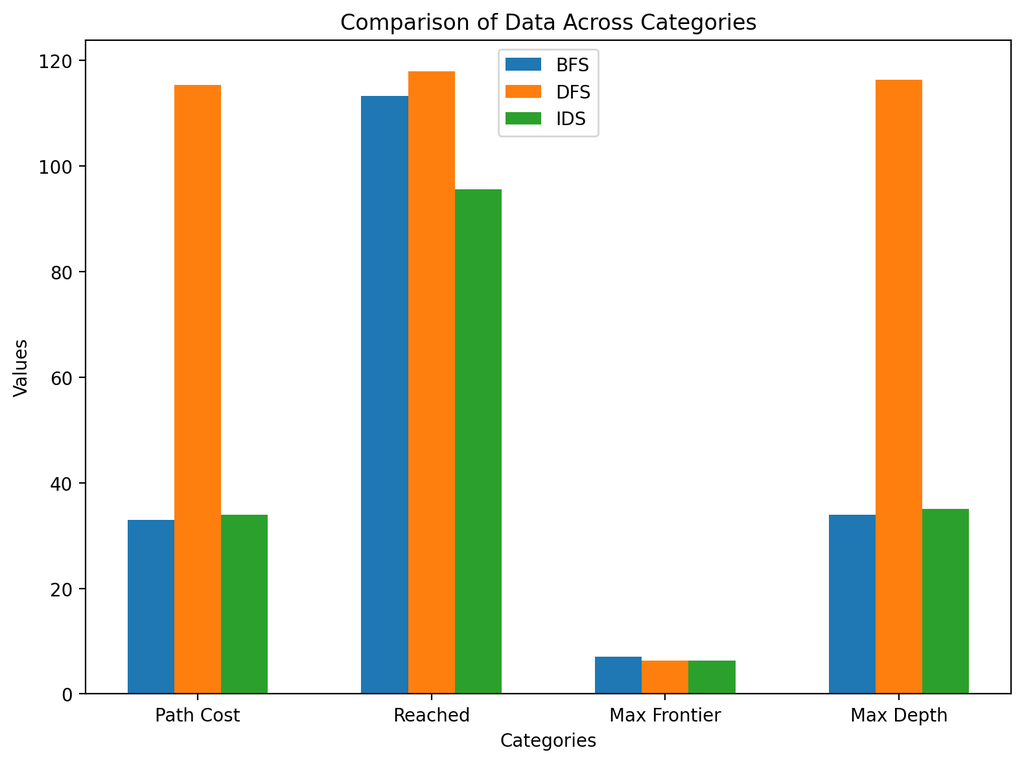

```python
import matplotlib.pyplot as plt
import numpy as np

categories = ['Path Cost', 'Reached', 'Max Frontier', 'Max Depth']
values_1 = [np.mean(BFS_bonus[key]) for key in categories]
values_2 = [np.mean(DFS_bonus[key]) for key in categories]
values_3 = [np.mean(IDS_bonus[key]) for key in categories]

# Set up the plot
x = np.arange(len(categories))  # the label locations
width = 0.2  # the width of the bars

fig, ax = plt.subplots(figsize=(8, 6))

# Plotting the bars for each dataset
bars1 = ax.bar(x - width, values_1, width, label='BFS')
bars2 = ax.bar(x, values_2, width, label='DFS')
bars3 = ax.bar(x + width, values_3, width, label='IDS')

# Labeling
ax.set_xlabel('Categories')
ax.set_ylabel('Values')
ax.set_title('Comparison of Data Across Categories')
ax.set_xticks(x)
ax.set_xticklabels(categories)
ax.legend()

# Display the plot
plt.tight_layout()
plt.show()
```

```python
!jupyter nbconvert --to html NSMaze.ipynb
```

[output not shown]

[output cut: 136 more lines]

[output not shown]

## More advanced tasks to think about

### Intersection as states

Instead of defining each square as a state, use only intersections as states. Now the storage requirement is reduced, but the path length between two intersections can be different. If we use total path length measured as the number of squares as path cost, how can we make sure that BFS and iterative deepening search is optimal? Change the code to do so.

```python
# Your code/answer goes here
```

### Weighted A* search

Modify your A* search to add weights (see text book) and explore how different weights influence the result.

```python
# Your code/answer goes here
```

### Unknown Maze

What happens if the agent does not know the layout of the maze in advance? This means that the agent faces an unknown environment, where it does not know the transition function. How does the environment look then (PEAS description)? How would you implement a rational agent to solve the maze? What if the agent still has a GPS device to tell the distance to the goal?

```python
# Your code/answer goes here
```